# Отчет по лабораторной работе № 6

Установка и настройка системы управления базами данных MariaDB

Бызова Мария Олеговна

2025-09-23

## Цель работы

Целью данной работы является приобретение практических навыков по установке и конфигурированию системы управления базами данных на примере программного обеспечения MariaDB.

## Установка MariaDB

Загрузим нашу операционную систему и перейдём в рабочий каталог с проектом. Далее запустим виртуальную машину server (рис. 1)

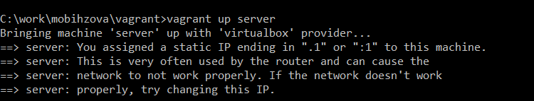

Рисунок 1: Открытие рабочего каталога с проектом и запуск виртуальной машины server.

## Установка MariaDB

На виртуальной машине server войдём под нашим пользователем и откроем терминал. Далееперейдём в режим суперпользователя и установим необходимые для работы с базами данных пакеты (рис. 2)

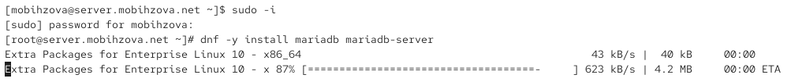

Рисунок 2: Переход в режим суперпользователя и установка необходимых для работы с базами данных пакетов

## Установка MariaDB

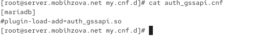

Рисунок 3: auth_gssapi.cnf

## Установка MariaDB

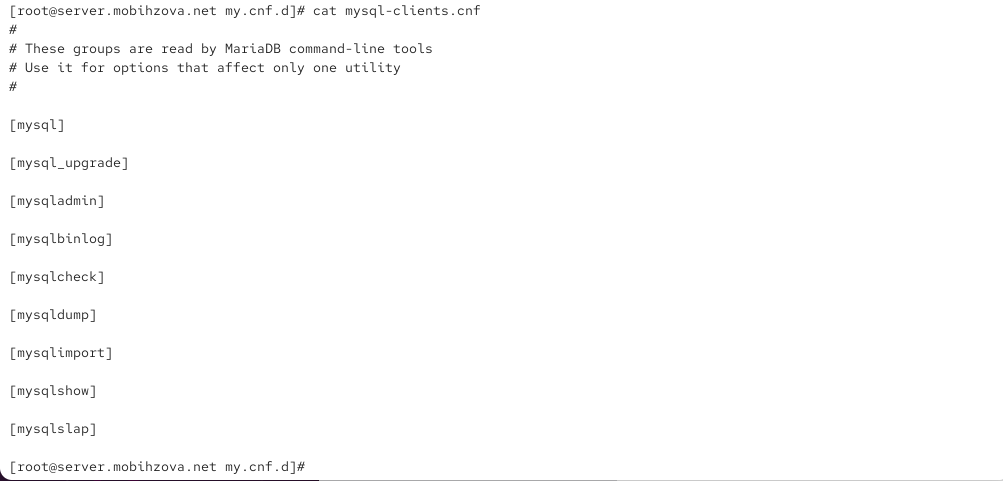

Рисунок 4: mysql-clients.cnf

## Установка MariaDB

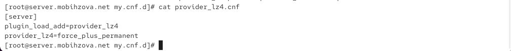

Рисунок 5: provider_lz4.cnf

## Установка MariaDB

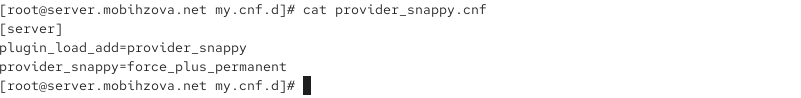

Рисунок 6: provider_snappy.cnf

## Установка MariaDB

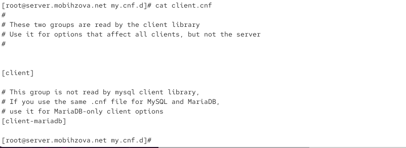

Рисунок 7: client.cnf

## Установка MariaDB

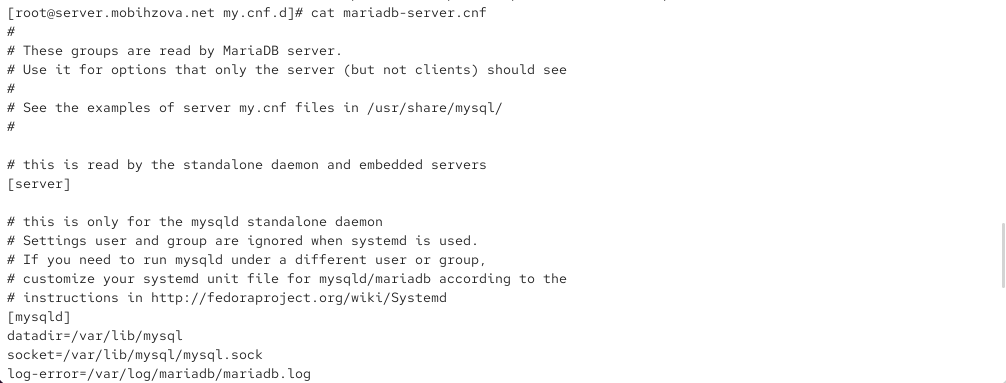

Рисунок 8: mariadb-server.cnf

## Установка MariaDB

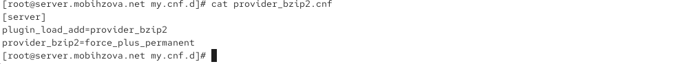

Рисунок 9: provider_bzip2.cnf

## Установка MariaDB

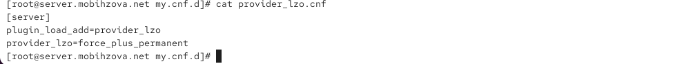

Рисунок 10: provider_lzo.cnf

## Установка MariaDB

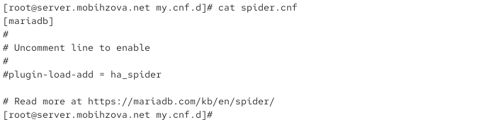

Рисунок 11: spider.cnf

## Установка MariaDB

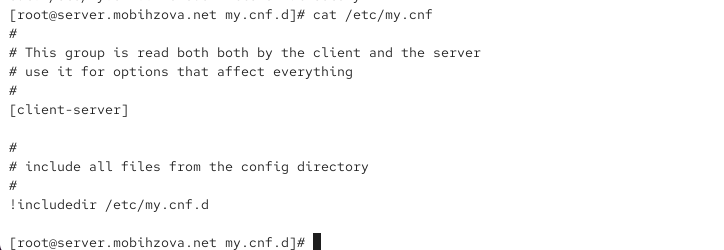

Рисунок 12: /etc/my.cnf

## Установка MariaDB

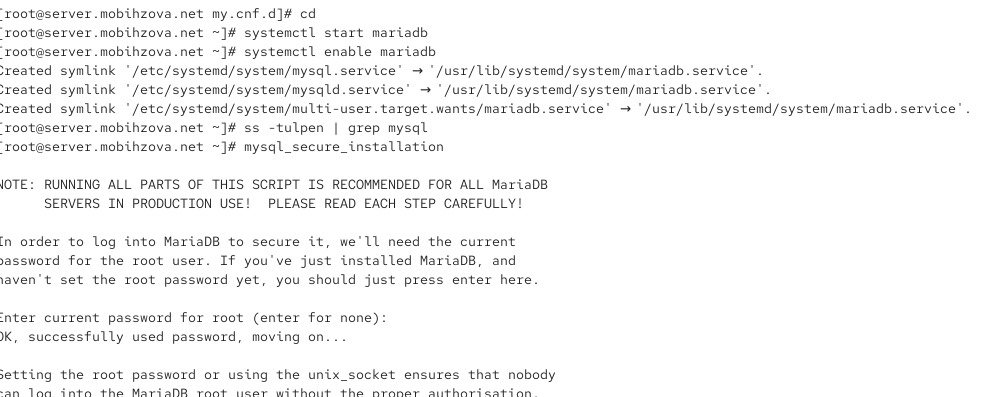

Рисунок 13: Запуск и включение программного обеспечения mariadb, проверка прослушивания порта, запуск скрипта конфигурации безопасности mariadb

## Установка MariaDB

Для входа в базу данных с правами администратора базы данных введём: mysql -u root -p. После чего просмотрим список команд MySQL, введя команду (рис. 14)

## Установка MariaDB

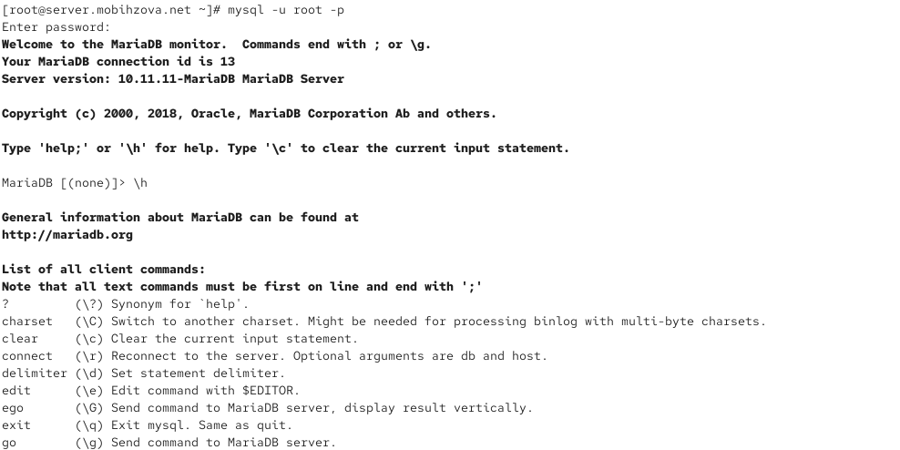

Рисунок 14: Вход в базу данных с правами администратора базы данных и просмотр списка команд MySQL.

## Установка MariaDB

Из приглашения интерактивной оболочки MariaDB для отображения доступных в настоящее время баз данных введём MySQL-запрос: SHOW DATABASES. Для выхода из интерфейса интерактивной оболочки MariaDB введём exit (рис. 15)

## Установка MariaDB

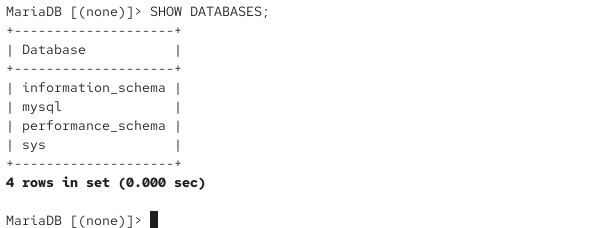

Рисунок 15: Отображение доступных в настоящее время баз данных и выход из интерфейса интерактивной оболочки MariaDB.

## Конфигурация кодировки символов

Войдём в базу данных с правами администратора. Для отображения статуса MariaDB введём из приглашения интерактивной оболочки MariaDB status (рис. 16).

## Конфигурация кодировки символов

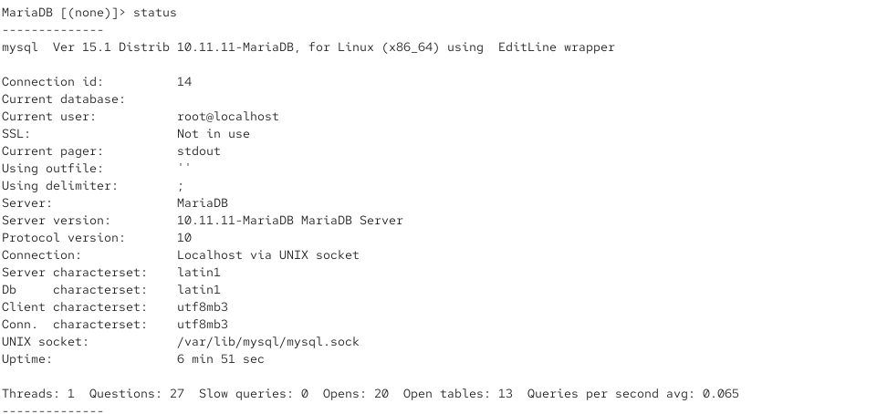

Рисунок 16: Вход в базу данных с правами администратора, отображение статуса MariaDB.

## Конфигурация кодировки символов

В каталоге /etc/my.cnf.d создадим файл utf8.cnf (рис. 17)

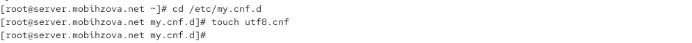

Рисунок 17: Создание файла utf8.cnf в каталоге /etc/my.cnf.d.

## Конфигурация кодировки символов

Откроем его на редактирование и укажем в нём следующую конфигурацию (рис. 18).

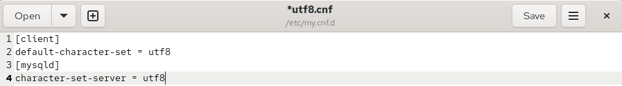

Рисунок 18: Открытие файла на редактирование и указание в нём конфигурации.

## Конфигурация кодировки символов

Перезапустим MariaDB (рис. 19)

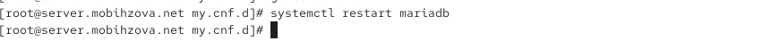

Рисунок 19: Перезапуск MariaDB

## Конфигурация кодировки символов

Войдём повторно в базу данных с правами администратора и посмотрим статус MariaDB для проверки изменений (рис. 20)

## Конфигурация кодировки символов

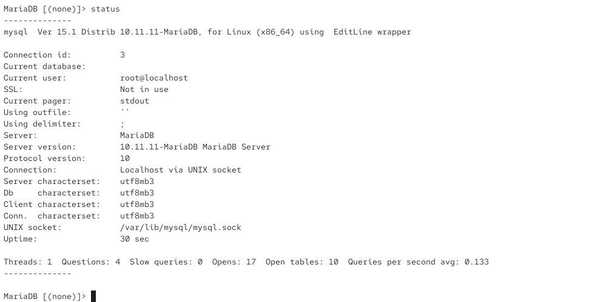

Рисунок 20: Вход в базу данных с правами администратора и просмотр статуса MariaDB для проверки изменений.

## Создание базы данных

Войдём в базу данных с правами администратора. Создадим базу данных с именем addressbook. Теперь перейдём к базе данных addressbook. Отобразим имеющиеся в базе данных addressbook таблицы. Создадим таблицу city с полями name и city. И заполним несколько строк таблицы некоторыми данными по аналогии в соответствии с синтаксисом MySQL. В частности, добавим в базу сведения о Петрове и Сидорове (рис. 21)

## Создание базы данных

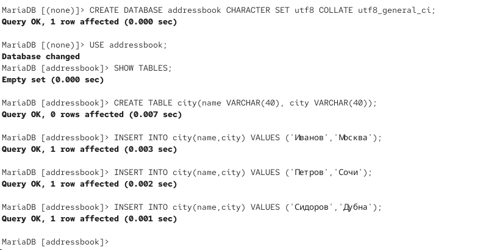

Рисунок 21: Вход в базу данных с правами администратора, создание базы данных с именем addressbook, открытие базы данных addressbook, отображение имеющиеся в базе данных addressbook таблицы. Создание таблицы city с полями name и city и заполнение таблицы некоторыми данными в соответствии с синтаксисом MySQL.

## Создание базы данных

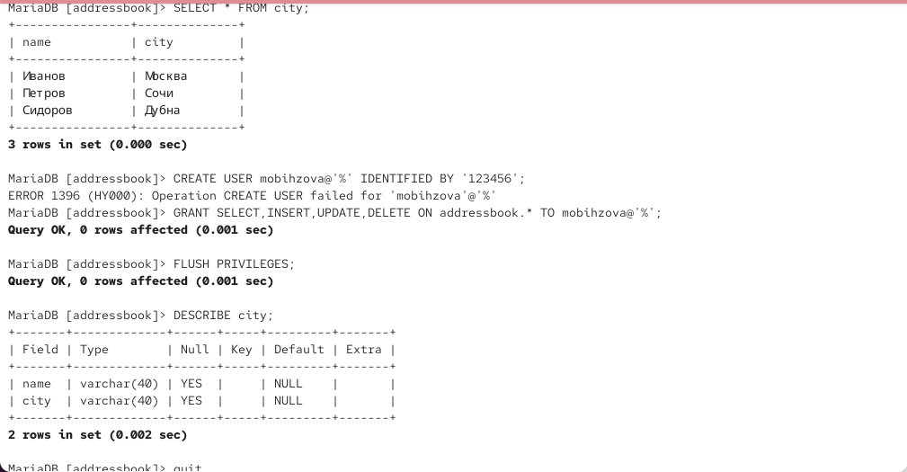

## Создание базы данных

Просмотрим список баз данных. Отдельно просмотрим список таблиц базы данных addressbook (рис. 23)

## Создание базы данных

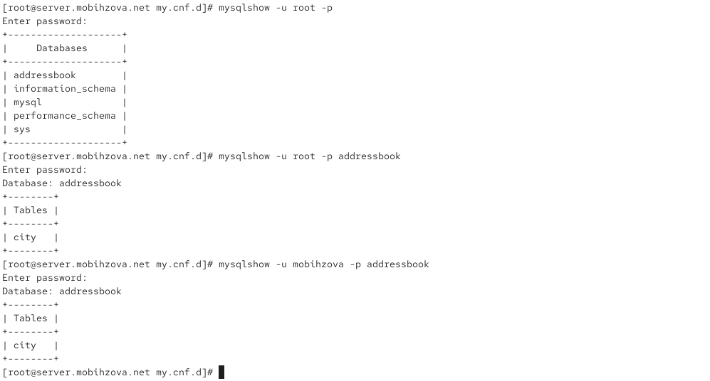

Рисунок 23: Просмотр списка баз данных и списка таблиц базы данных addressbook.

## Резервные копии

На виртуальной машине server создадим каталог для резервных копий. Сделаем резервную копию базы данных addressbook. Сделаем сжатую резервную копию базы данных addressbook. Сделаем сжатую резервную копию базы данных addressbook с указанием даты создания копии. Восстановим базу данных addressbook из резервной копии. Восстановим базу данных addressbook из сжатой резервной копии (рис. 24)

## Резервные копии

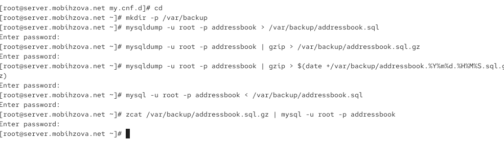

Рисунок 24: Создание каталога для резервных копий, создание резервной копии базы данных addressbook, создание сжатой резервной копии базы данных addressbook, создание сжатой резервной копии базы данных addressbook с указанием даты создания копии, восстановление базы данных addressbook из резервной копии, восстановление базы данных addressbook из сжатой резервной копии.

## Внесение изменений в настройки внутреннего окружения виртуальной машины

На виртуальной машине server перейдём в каталог для внесения изменений в настройки внутреннего окружения /vagrant/provision/server/, создадим в нём каталог mysql, в который поместим в соответствующие подкаталоги конфигурационные файлы MariaDB и резервную копию базы данных addressbook (рис. 25)

## Внесение изменений в настройки внутреннего окружения виртуальной машины

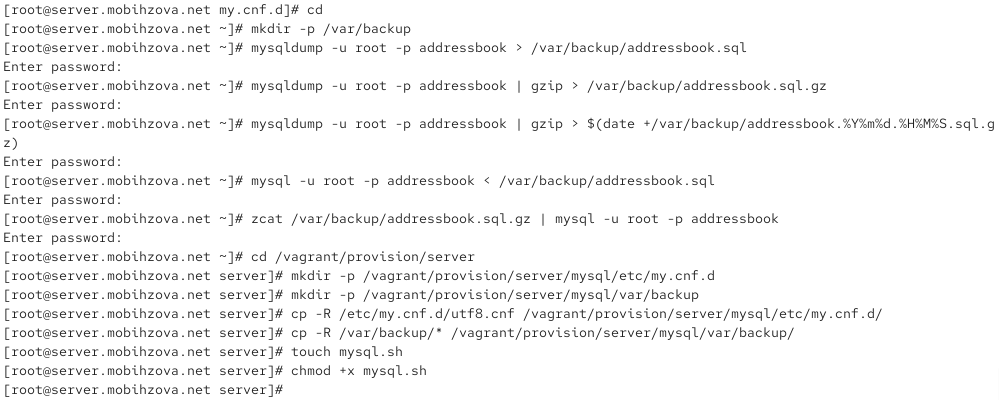

Рисунок 25: Открытие каталога для внесения изменений в настройки внутреннего окружения /vagrant/provision/server/, создание в нём каталога mysql, в который помещаем в соответствующие подкаталоги конфигурационные файлы MariaDB и резервную копию базы данных addressbook. Создание в каталоге /vagrant/provision/server исполняемого файла mysql.sh.

## Внесение изменений в настройки внутреннего окружения виртуальной машины

Откроем его на редактирование и пропишем в нём следующий скрипт (рис. 26)

## Внесение изменений в настройки внутреннего окружения виртуальной машины

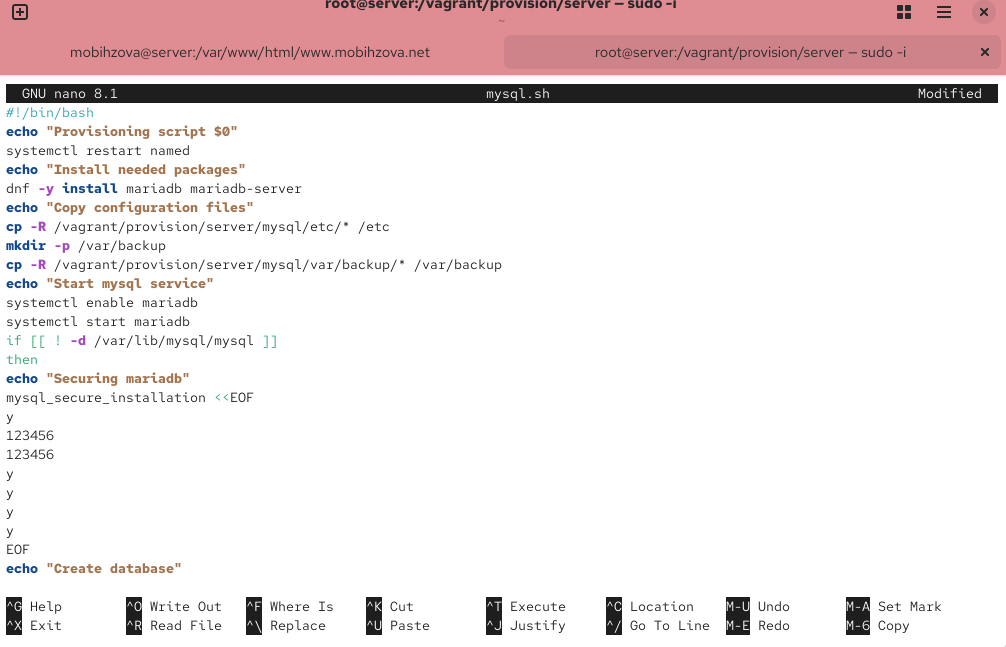

Рисунок 26: Открытие исполняемого файла на редактирование и прописывание в нём скрипта.

## Внесение изменений в настройки внутреннего окружения виртуальной машины

Для отработки созданного скрипта во время загрузки виртуальных машин в конфигурационном файле Vagrantfile добавим в конфигурации сервера следующую запись (рис. 27)

## Внесение изменений в настройки внутреннего окружения виртуальной машины

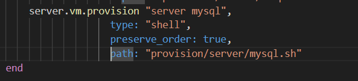

Рисунок 27: Добавление записи в конфигурационном файле Vagrantfile.

## Выводы

В ходе выполнения лабораторной работы были приобретены практические навыки по установке и конфигурированию системы управления базами данных на примере программного обеспечения MariaDB.